# Dataset Elliot_2006_i4B

This dataset from Elliot (2006) is published in Elliot (2020): https://doi.org/10.6084/m9.figshare.13028129.v1

- Contains n=290 feeding trials.
- Raw data is available for single-prey experiments. For multi-prey experiments, we replicated data from summary statistics.
- Experiments ran for 90 minutes.
- Eaten prey were replaced.
- We fitted direct FR predictions to the data.
- Holling-3 was identified as the best fitting model.
- The model predicts switching from avoidance to preference of prey 1.
- No systematic deviations of predicted values were observed.

## Setup

```r
rm(list=ls())
library("rstan")
library("loo")
library("coda")
library("deSolve")
library("BayesianTools")
```

Load MSFR functions that can be used with the `deSolve` package, used for posterior predictions later.

```r
source("desolve_models.R")
```

Compile Stan models. Can be skipped if already executed before, models are saved in `.Rdata` files.

```r
source("compilation_loo_mixed.R")
```

Load compiled Stan models.

```r
load("stan_model_H2_mixed.RData")
load("stan_model_H3_mixed.RData")
load("stan_model_Yo_mixed.RData")
load("stan_model_New_mixed.RData")
```

## Prepare data

For single-species experiments, raw data is available. For multi-species experiments, only means & standard deviations of `n` replicates of an offered prey combination (N01,N02) are available. A full dataset is replicated by drawing numbers of eaten prey from normal distributions with given means and standard deviations and rounded to the next integer. `df.all` includes all observations, `df.multi.rep` only multi-species experiments, `df.single.1` and `df.single.2` only single-species experiments, respectively.

```r
set.seed(100)

df = read.csv("Elliot_2006_Instar4Baet.csv")
head(df)
```

```
  Pred Prey1.B Prey2.L Prey1.Eaten.Mean Prey1.Eaten.95CI Prey1.Eaten.SE
1    1      20     180              0.2             0.30           0.15
2    1      40     160              0.9             0.41           0.21
3    1      60     140              2.1             0.41           0.21
4    1      80     120              3.8             0.74           0.38
5    1     100     100              5.6             0.37           0.19
6    1     120      80              7.2             0.74           0.38
  Prey2.Eaten.Mean Prey2.Eaten.95CI Prey2.Eaten.SE  n Time
1              9.4             1.23           0.63 10   90
2              8.7             0.59           0.30 10   90
3              7.5             0.61           0.31 10   90
4              5.8             0.56           0.29 10   90
5              4.0             0.75           0.38 10   90
6              2.4             0.50           0.26 10   90
```

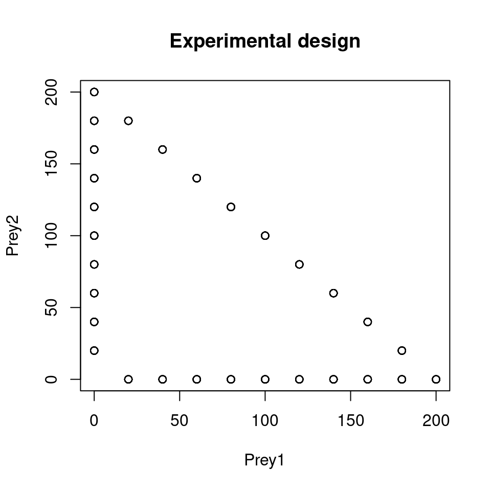

```r
colnames(df)[2:3] = c("Prey1","Prey2")
df.single.1 = subset(df, df$Prey2==0)
colnames(df.single.1)[c(4,7)] = c("Prey1.Eaten","Prey2.Eaten")
df.single.2 = subset(df, df$Prey1==0)
colnames(df.single.2)[c(4,7)] = c("Prey1.Eaten","Prey2.Eaten")
df.multi = subset(df, df$Prey2>0 & df$Prey1>0 )

df.multi.rep = data.frame(Prey1=c(),
                          Prey2=c(),
                          Prey1.Eaten=c(),
                          Prey2.Eaten=c()
)

for(i in 1:nrow(df.multi)){
  n = df.multi$n[i]
  Prey1.Eaten = rnorm(n, df.multi$Prey1.Eaten.Mean[i], df.multi$Prey1.Eaten.SE[i])
  Prey2.Eaten = rnorm(n, df.multi$Prey2.Eaten.Mean[i], df.multi$Prey2.Eaten.SE[i])
  Prey1.Eaten = round(Prey1.Eaten)
  Prey2.Eaten = round(Prey2.Eaten)
  df.multi.rep = rbind(df.multi.rep,
                       data.frame(Prey1=rep(df.multi$Prey1[i],n),
                                  Prey2=rep(df.multi$Prey2[i],n),
                                  Prey1.Eaten=Prey1.Eaten,
                                  Prey2.Eaten=Prey2.Eaten)
  )
}

df.all = data.frame(Prey1 = c(df.single.1$Prey1, df.single.2$Prey1, df.multi.rep$Prey1),
                    Prey2 = c(df.single.1$Prey2, df.single.2$Prey2, df.multi.rep$Prey2),
                    Prey1.Eaten = c(df.single.1$Prey1.Eaten, df.single.2$Prey1.Eaten, df.multi.rep$Prey1.Eaten),
                    Prey2.Eaten = c(df.single.1$Prey2.Eaten, df.single.2$Prey2.Eaten, df.multi.rep$Prey2.Eaten)
)

plot(df.all[, c(1,2)], main="Experimental design")
```

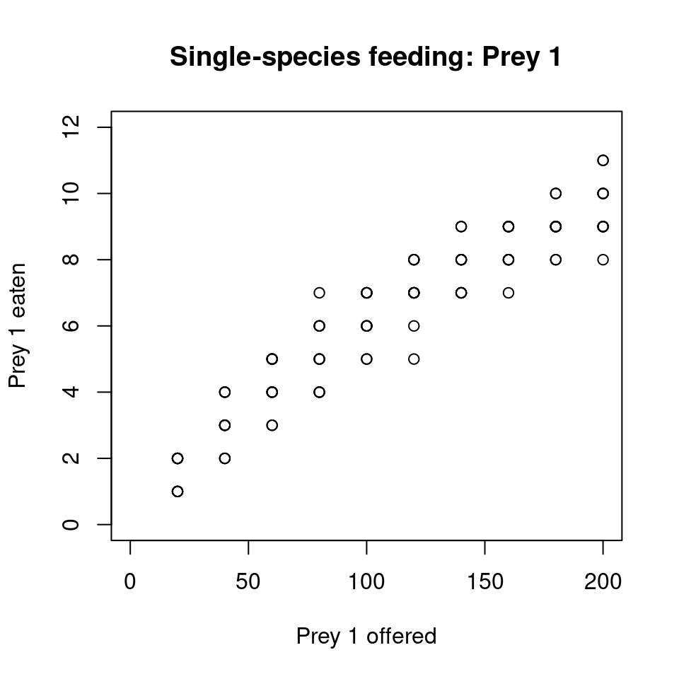

```r
plot(df.single.1$Prey1, df.single.1$Prey1.Eaten, xlim=c(0,200), ylim=c(0,12),
     xlab="Prey 1 offered", ylab="Prey 1 eaten",
     main="Single-species feeding: Prey 1")
```

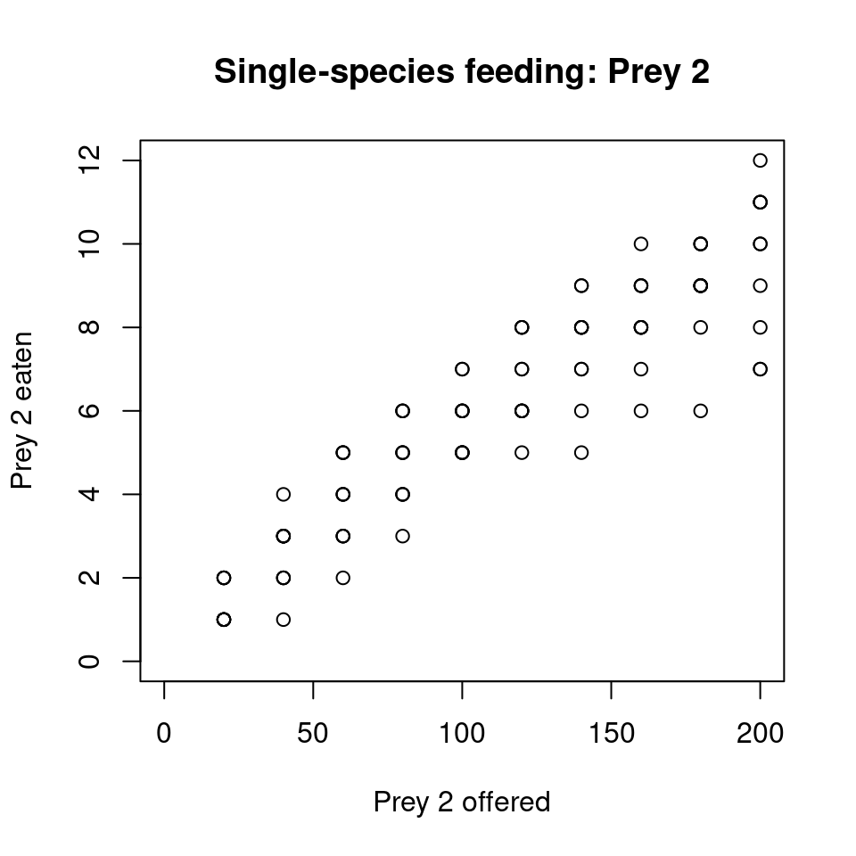

```r
plot(df.single.2$Prey2, df.single.2$Prey2.Eaten, xlim=c(0,200), ylim=c(0,12),
     xlab="Prey 2 offered", ylab="Prey 2 eaten",
     main="Single-species feeding: Prey 2")
```

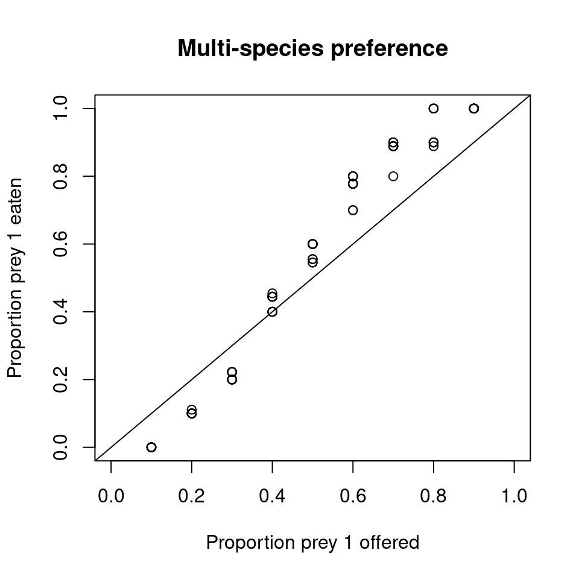

```r
plot(df.multi.rep$Prey1/(df.multi.rep$Prey1+df.multi.rep$Prey2),
     df.multi.rep$Prey1.Eaten/(df.multi.rep$Prey1.Eaten+df.multi.rep$Prey2.Eaten),
     xlim=c(0,1), ylim=c(0,1),
     xlab="Proportion prey 1 offered", ylab="Proportion prey 1 eaten",
     main="Multi-species preference")
abline(0,1)
```

Data has to be coded as a named list for `Stan`. Generic duration of experiments `Time=1.0` is provided, and all experiments were conducted with prey replacement `Replaced=1`.

```r
data.stan = list(n = nrow(df.all),
                 m = 2,
                 N_0 = df.all[, 1:2],
                 N_e = df.all[, 3:4],
                 Time = rep(1.0, nrow(df.all)),
                 Replaced = rep(1, nrow(df.all))
)
```

## Model fitting

For all models, posterior distributions are sampled using 3 chains, 1000 warmup steps and 2000 sampling steps, each. Initial values `init` are provided for all parameters. Convergence of MCMC is verified through `Rhat` value close to 1 and sufficient number of effective samples `n_eff`.

```r
chains = 3
```

### Fit Holling 2

```r
init = rep(list(list(a = c(1.0,1.0),
                     h = c(1/5,1/5))
),chains)

fit1 = sampling(
  model.H2,
  data = data.stan,
  chains = chains,
  warmup = 1000,
  iter = 3000,
  cores = 3,
  init = init,
  refresh = 100
)
```

```r
print(fit1, pars=c("a","h"))
```

```
Inference for Stan model: anon_model.
3 chains, each with iter=3000; warmup=1000; thin=1;
post-warmup draws per chain=2000, total post-warmup draws=6000.

     mean se_mean   sd 2.5%  25%  50%  75% 97.5% n_eff Rhat
a[1] 0.09       0 0.01 0.08 0.08 0.09 0.10  0.11  1661    1
a[2] 0.07       0 0.01 0.06 0.07 0.07 0.08  0.09  1583    1
h[1] 0.05       0 0.01 0.03 0.04 0.05 0.06  0.06  1856    1
h[2] 0.03       0 0.01 0.01 0.03 0.03 0.04  0.05  1722    1

Samples were drawn using NUTS(diag_e) at Mon Oct 30 13:31:20 2023.
For each parameter, n_eff is a crude measure of effective sample size,
and Rhat is the potential scale reduction factor on split chains (at
convergence, Rhat=1).
```

### Fit Holling 3

```r
init = rep(list(list(a = c(0.1,0.1),
                     h = c(1/5,1/5),
                     q = 1)
),chains)

fit2 = sampling(
  model.H3,
  data = data.stan,
  chains = chains,
  warmup = 1000,
  iter = 3000,
  cores = 3,
  init = init,
  refresh = 100
)
```

```r
print(fit2, pars=c("a","h","q"))
```

```
Inference for Stan model: anon_model.
3 chains, each with iter=3000; warmup=1000; thin=1;
post-warmup draws per chain=2000, total post-warmup draws=6000.

     mean se_mean   sd 2.5%  25%  50%  75% 97.5% n_eff Rhat
a[1] 0.01       0 0.00 0.00 0.01 0.01 0.01  0.02  1285 1.00
a[2] 0.01       0 0.00 0.00 0.01 0.01 0.01  0.01  1286 1.00
h[1] 0.09       0 0.01 0.07 0.08 0.09 0.09  0.10  1656 1.01
h[2] 0.08       0 0.01 0.06 0.07 0.08 0.08  0.09  1641 1.01
q    0.63       0 0.10 0.44 0.56 0.62 0.69  0.84  1120 1.01

Samples were drawn using NUTS(diag_e) at Mon Oct 30 13:32:04 2023.
For each parameter, n_eff is a crude measure of effective sample size,
and Rhat is the potential scale reduction factor on split chains (at
convergence, Rhat=1).
```

### Fit Yodzis FR

```r
init = rep(list(list(a = c(1,1),
                     h = c(1/5,1/5),
                     w = c(0.5,0.5),
                     r = 1)
),chains)

fit3 = sampling(
  model.Yo,
  data = data.stan,
  chains = chains,
  warmup = 1000,
  iter = 3000,
  cores = 3,
  init = init,
  refresh = 100
)
```

```r
print(fit3, pars=c("a","h","w","r"))
```

```
Inference for Stan model: anon_model.
3 chains, each with iter=3000; warmup=1000; thin=1;
post-warmup draws per chain=2000, total post-warmup draws=6000.

     mean se_mean   sd 2.5%  25%  50%  75% 97.5% n_eff Rhat
a[1] 0.12       0 0.02 0.09 0.10 0.11 0.13  0.15  2298    1
a[2] 0.09       0 0.01 0.07 0.08 0.09 0.10  0.11  3056    1
h[1] 0.05       0 0.01 0.04 0.05 0.05 0.06  0.07  2448    1
h[2] 0.04       0 0.01 0.02 0.03 0.04 0.05  0.06  3031    1
w[1] 0.53       0 0.05 0.43 0.50 0.53 0.56  0.63  2563    1
w[2] 0.47       0 0.05 0.37 0.44 0.47 0.50  0.57  2563    1
r    1.12       0 0.13 0.87 1.03 1.12 1.21  1.39  4229    1

Samples were drawn using NUTS(diag_e) at Mon Oct 30 13:32:39 2023.
For each parameter, n_eff is a crude measure of effective sample size,
and Rhat is the potential scale reduction factor on split chains (at
convergence, Rhat=1).
```

### Fit New FR

```r
init = rep(list(list(a = c(1,1),
                     h = c(1/5,1/5),
                     w = c(0.5,0.5),
                     q = 0.1,
                     r = 0.1)
),chains)

fit4 = sampling(
  model.New,
  data = data.stan,
  chains = chains,
  warmup = 1000,
  iter = 3000,
  cores = 3,
  init = init,
  refresh = 100
)
```

```r
print(fit4, pars=c("a","h","w","q","r"))
```

```
Inference for Stan model: anon_model.
3 chains, each with iter=3000; warmup=1000; thin=1;
post-warmup draws per chain=2000, total post-warmup draws=6000.

     mean se_mean   sd 2.5%  25%  50%  75% 97.5% n_eff Rhat
a[1] 0.06    0.00 0.03 0.02 0.04 0.05 0.08  0.12   821    1
a[2] 0.04    0.00 0.02 0.01 0.03 0.04 0.06  0.09   711    1
h[1] 0.07    0.00 0.01 0.05 0.06 0.07 0.08  0.09   948    1
h[2] 0.06    0.00 0.01 0.03 0.05 0.06 0.07  0.08  1050    1
w[1] 0.53    0.00 0.05 0.43 0.49 0.53 0.56  0.62  2176    1
w[2] 0.47    0.00 0.05 0.38 0.44 0.47 0.51  0.57  2176    1
q    0.23    0.01 0.14 0.01 0.11 0.22 0.33  0.54   678    1
r    0.90    0.01 0.19 0.51 0.76 0.90 1.03  1.26   948    1

Samples were drawn using NUTS(diag_e) at Mon Oct 30 13:34:39 2023.
For each parameter, n_eff is a crude measure of effective sample size,
and Rhat is the potential scale reduction factor on split chains (at
convergence, Rhat=1).
```

## Model comparison

Extract log-likelihood values for all fits and compute predictive performance with leave-one-out cross validation using the `loo` package.

```r
lik1 = extract_log_lik(fit1, merge_chains=FALSE)
reff1 = relative_eff(exp(lik1), cores=4)
loo1 = loo(lik1, r_eff=reff1, cores=4)

lik2 = extract_log_lik(fit2, merge_chains=FALSE)
reff2 = relative_eff(exp(lik2), cores=4)
loo2 = loo(lik2, r_eff=reff2, cores=4)

lik3 = extract_log_lik(fit3, merge_chains=FALSE)
reff3 = relative_eff(exp(lik3), cores=4)
loo3 = loo(lik3, r_eff=reff3, cores=4)

lik4 = extract_log_lik(fit4, merge_chains=FALSE)
reff4 = relative_eff(exp(lik4), cores=4)
loo4 = loo(lik4, r_eff=reff4, cores=4)

loo_compare(loo1, loo2, loo3, loo4)
```

```
       elpd_diff se_diff
model2   0.0       0.0
model4 -16.6       2.8
model3 -18.0       3.1
model1 -29.2       4.5
```

Holling-3 is identified as the best fitting model.

Its posterior distributions of all parameters and their multivariate correlation are plotted.

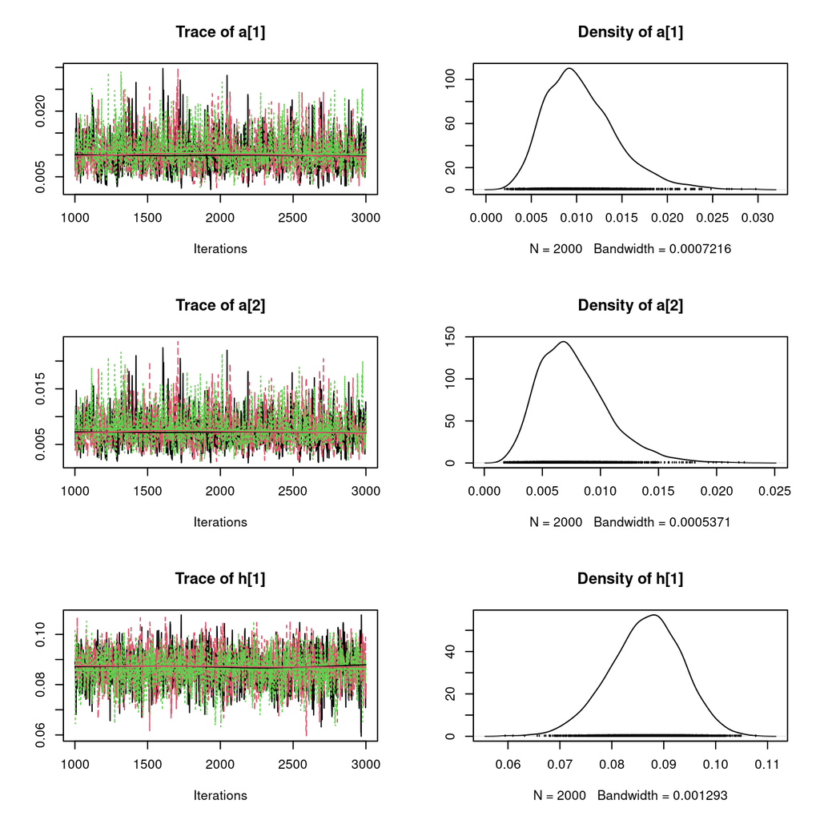

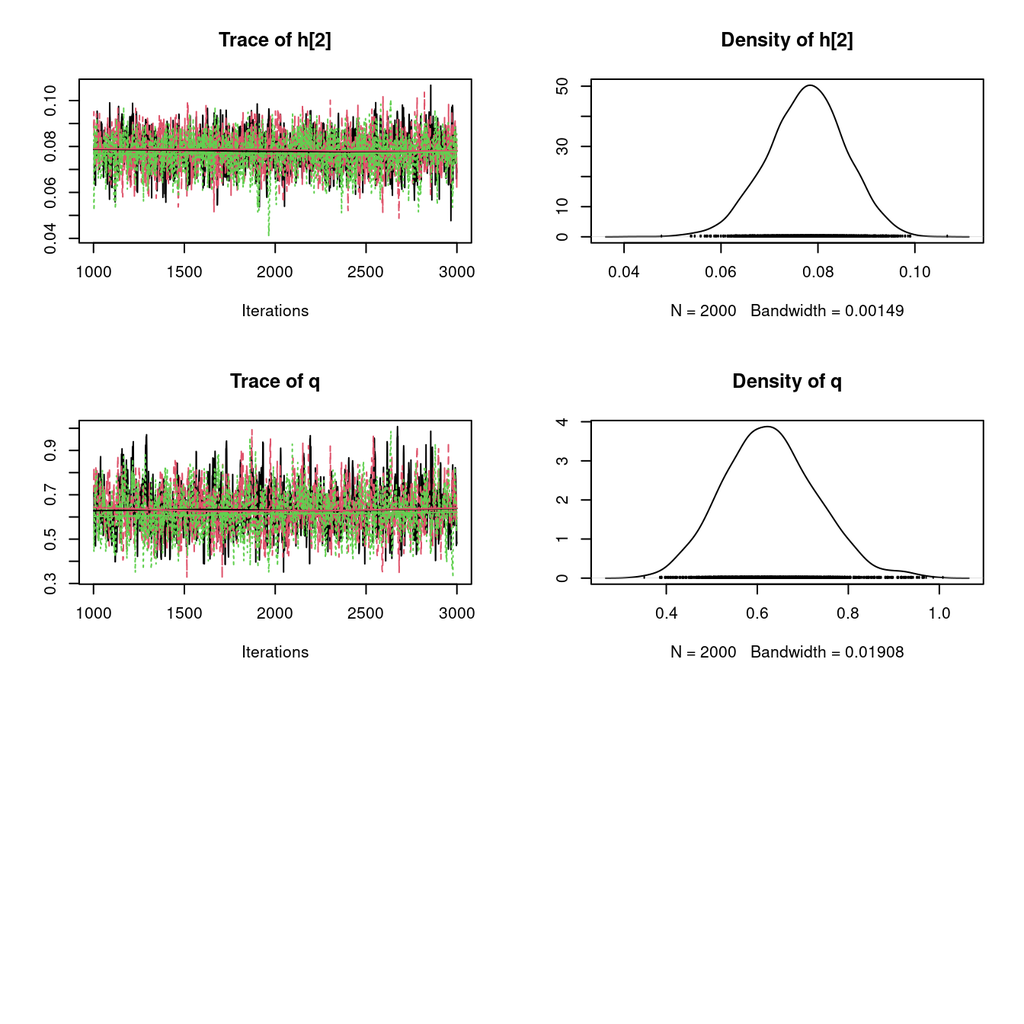

```r
plot(As.mcmc.list(fit2)[, 1:5])
```

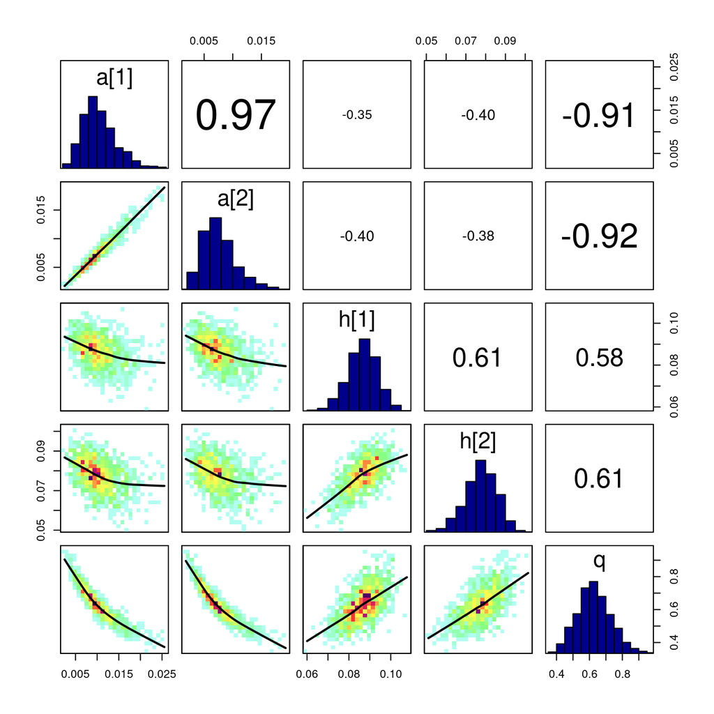

```r
correlationPlot(as.matrix(fit2)[, 1:5])
```

## Posterior predictions for best fitting model

The correct `MSFR` model function is selected, which has the output (negative) functional response. 1000 samples from the posterior distribution are chosen randomly. Since prey were replaced, predictions are computed directly as feeding rate multiplied by experimental duration. Their median and 90% credible intervals are plotted against observed data.

```r
MSFR = Holling3

n.post = 1000
n.pred = 20
post = as.matrix(fit2)[, 1:5]
set.seed(100)
post = post[sample(1:nrow(post),n.post), ]
```

### Single-species prey 1

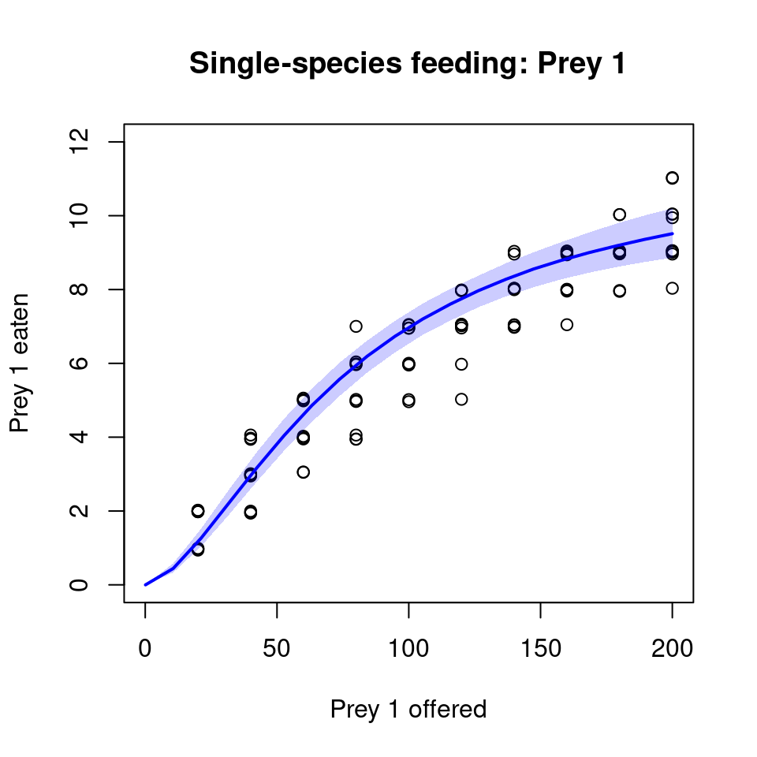

```r
N10.pred = seq(0.1, 200, length.out=n.pred)
N1E.pred = matrix(NA, nrow=n.post, ncol=n.pred)

for(k in 1:n.post){
  params = list(a=post[k, 1:2],
                h=post[k, 3:4],
                q=post[k, 5],
                m=2)
  for(i in 1:n.pred){
    out = -1.0*unlist(MSFR(t=0, N=c(N10.pred[i], 0.0), parms=params))
    N1E.pred[k,i] = out[1]
  }
}

N1E.pred.qs = apply(N1E.pred, 2, function(x) quantile(x, probs=c(0.05, 0.5, 0.95)))

plot(df.single.1$Prey1, jitter(df.single.1$Prey1.Eaten, factor=0.3),
     xlim=c(0,200), ylim=c(0,12),
     xlab="Prey 1 offered", ylab="Prey 1 eaten",
     main="Single-species feeding: Prey 1")
polygon( c(N10.pred, rev(N10.pred)),
         c(N1E.pred.qs[1, ], rev(N1E.pred.qs[3, ])),
         border=NA,
         col=adjustcolor("blue", alpha.f=0.2)
)
lines(N10.pred, N1E.pred.qs[2, ], col="blue", lwd=2)
```

### Single-species prey 2

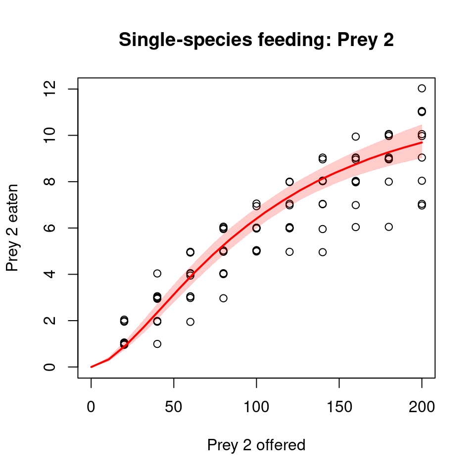

```r
N20.pred = seq(0.1, 200, length.out=n.pred)
N2E.pred = matrix(NA, nrow=n.post, ncol=n.pred)

for(k in 1:n.post){
  params = list(a=post[k, 1:2],
                h=post[k, 3:4],
                q=post[k, 5],
                m=2)
  for(i in 1:n.pred){
    out = -1.0*unlist(MSFR(t=0, N=c(0.0, N20.pred[i]), parms=params))
    N2E.pred[k,i] = out[2]
  }
}

N2E.pred.qs = apply(N2E.pred, 2, function(x) quantile(x, probs=c(0.05, 0.5, 0.95)))

plot(df.single.2$Prey2, jitter(df.single.2$Prey2.Eaten, factor=0.3),
     xlim=c(0,200), ylim=c(0,12),
     xlab="Prey 2 offered", ylab="Prey 2 eaten",
     main="Single-species feeding: Prey 2")
polygon( c(N20.pred, rev(N20.pred)),
         c(N2E.pred.qs[1, ], rev(N2E.pred.qs[3, ])),
         border=NA,
         col=adjustcolor("red", alpha.f=0.2)
)
lines(N20.pred, N2E.pred.qs[2, ], col="red", lwd=2)
```

### Multi-species relative consumption

Multi-species predictions are computed along a gradient of relative composition of N1 and N2 with N1+N2=200.

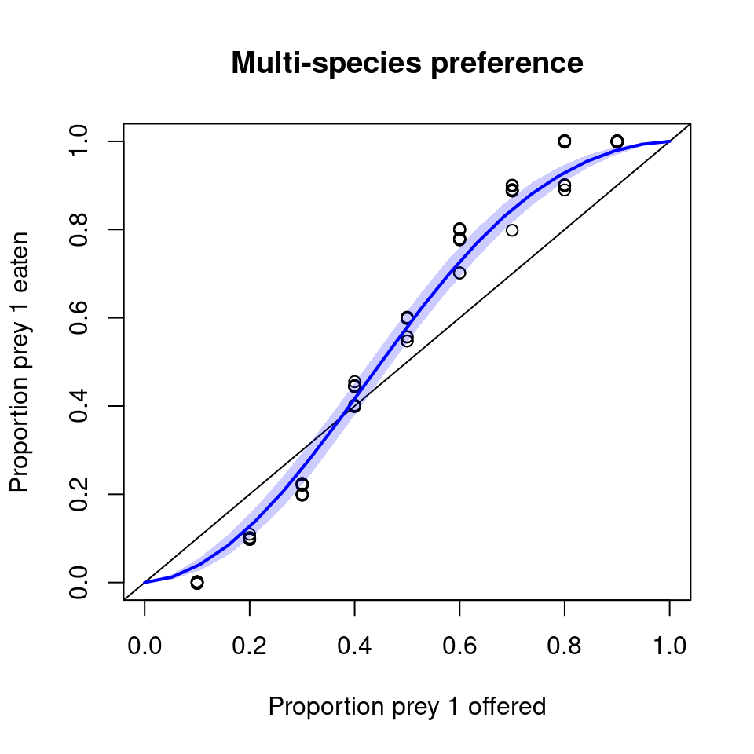

```r
N0.total = 200

N10.pred = seq(0, N0.total, length.out=n.pred)
N20.pred = N0.total-N10.pred
N1E.pred = matrix(NA, nrow=n.post, ncol=n.pred)
N2E.pred = matrix(NA, nrow=n.post, ncol=n.pred)

for(k in 1:n.post){
  params = list(a=post[k, 1:2],
                h=post[k, 3:4],
                q=post[k, 5],
                m=2)
  for(i in 1:n.pred){
    out = -1.0*unlist(MSFR(t=0, N=c(N10.pred[i], N20.pred[i]), parms=params))
    N1E.pred[k,i] = out[1]
    N2E.pred[k,i] = out[2]
  }
}

N1E.pred.qs = apply(N1E.pred, 2, function(x) quantile(x, probs=c(0.05, 0.5, 0.95)))
N2E.pred.qs = apply(N2E.pred, 2, function(x) quantile(x, probs=c(0.05, 0.5, 0.95)))

# make relative
N1E.pred.rel = matrix(NA, nrow=n.post, ncol=n.pred)
N2E.pred.rel = matrix(NA, nrow=n.post, ncol=n.pred)
for(k in 1:n.post){
  N1E.pred.rel[k, ] = N1E.pred[k, ]/(N1E.pred[k, ]+N2E.pred[k, ])
  N2E.pred.rel[k, ] = N2E.pred[k, ]/(N1E.pred[k, ]+N2E.pred[k, ])
}

N1E.pred.rel.qs = apply(N1E.pred.rel, 2, function(x) quantile(x, probs=c(0.05, 0.5, 0.95)))
N2E.pred.rel.qs = apply(N2E.pred.rel, 2, function(x) quantile(x, probs=c(0.05, 0.5, 0.95)))

plot(df.multi.rep$Prey1/(df.multi.rep$Prey1+df.multi.rep$Prey2),
     jitter(df.multi.rep$Prey1.Eaten/(df.multi.rep$Prey1.Eaten+df.multi.rep$Prey2.Eaten),factor=1),
     xlim=c(0,1), ylim=c(0,1),
     xlab="Proportion prey 1 offered", ylab="Proportion prey 1 eaten",
     main="Multi-species preference")
abline(0,1)
polygon( c(N10.pred/N0.total, rev(N10.pred/N0.total)),
         c(N1E.pred.rel.qs[1, ], rev(N1E.pred.rel.qs[3, ])),
         border=NA,
         col=adjustcolor("blue", alpha.f=0.2)
)
lines(N10.pred/N0.total, N1E.pred.rel.qs[2, ], col="blue", lwd=2)
```

The model predicts switching from avoidance to preference of prey 1.

### Multi-species feeding

Since multi-species experiments were performed with a fixed number of total prey only (N1+N2=200), predicted feeding rates on both species can be plotted along this gradient against the data.

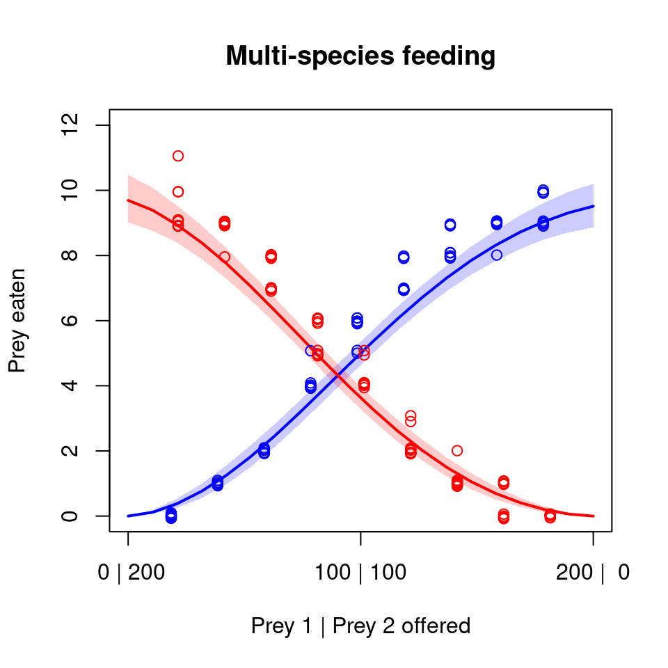

```r
plot(NA, xlim=c(0,200), ylim=c(0,12), xaxt="n", ylab="", xlab="",
     main="Multi-species feeding")
title(ylab="Prey eaten", xlab="Prey 1 | Prey 2 offered")
axis(1, at = c(0,100,200), labels = c(" 0 | 200", "100 | 100", "200 |  0"))
polygon( c(N10.pred, rev(N10.pred)),
         c(N1E.pred.qs[1, ], rev(N1E.pred.qs[3, ])),
         border=NA,
         col=adjustcolor("blue", alpha.f=0.2)
)
polygon( c(200-N20.pred, rev(200-N20.pred)),
         c(N2E.pred.qs[1, ], rev(N2E.pred.qs[3, ])),
         border=NA,
         col=adjustcolor("red", alpha.f=0.2)
)
lines(N10.pred, N1E.pred.qs[2, ], col="blue", lwd=2)
lines(200-N20.pred, N2E.pred.qs[2, ], col="red", lwd=2)
points(jitter(df.multi.rep$Prey1, factor=0.0)-1.5,
       jitter(df.multi.rep$Prey1.Eaten, factor=0.5),
       col="blue")
points(jitter(200-(df.multi.rep$Prey2), factor=0.0)+1.5, # reverse
       jitter(df.multi.rep$Prey2.Eaten, factor=0.5),
       col="red")
```

### Multi-species observed vs. predicted

Additionally, median predicted numbers of eaten prey (N1E and N2E) are computed and plotted against observed data points.

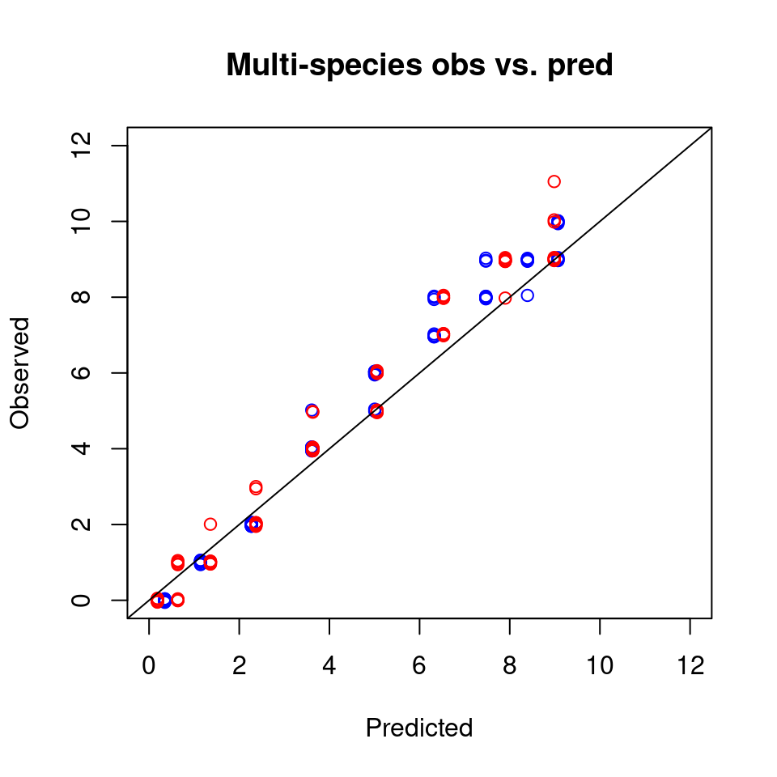

```r
N1E.pred = matrix(NA, nrow=n.post, ncol=nrow(df.multi.rep))
N2E.pred = matrix(NA, nrow=n.post, ncol=nrow(df.multi.rep))

for(k in 1:n.post){
  params = list(a=post[k, 1:2],
                h=post[k, 3:4],
                q=post[k, 5],
                m=2)
  for(i in 1:nrow(df.multi.rep)){
    out = -1.0*unlist(MSFR(t=0, N=c(df.multi.rep$Prey1[i],df.multi.rep$Prey2[i]), parms=params))
    N1E.pred[k,i] = out[1]
    N2E.pred[k,i] = out[2]
  }
}

N1E.pred.qs = apply(N1E.pred, 2, function(x) quantile(x, probs=c(0.05, 0.5, 0.95)))
N2E.pred.qs = apply(N2E.pred, 2, function(x) quantile(x, probs=c(0.05, 0.5, 0.95)))

plot(NULL, xlim=c(0,12), ylim=c(0,12), xlab="Predicted", ylab="Observed",
     main="Multi-species obs vs. pred")
points(N1E.pred.qs[2, ], jitter(df.multi.rep$Prey1.Eaten, factor=0.3), col="blue")
points(N2E.pred.qs[2, ], jitter(df.multi.rep$Prey2.Eaten, factor=0.3), col="red")
abline(0,1)
```